# Life history An darlingi Brazil Statistical analysis 11/2/2017

Virginia Chu

November 2, 2017

## Life history data description

# Description of columns:

## Independent variables

- Biome [Amazon, Cerrado, Mata Atlantica]- Categorical/nominal
  - State [Amazonas, Rondonia, Tocantins, Mata Atlantica]-Ordinal
  - Locality [ARS, APR, RPV, RMO, TLC, TPN, SJU]-Ordinal
  - Latitude [-2.864, -3.028, -8.742, -9.223, -10.7, -10.796, -22.611 ]- Ordinal
- Lat_group- 1 (low, near equator), 2 (mid), 3 (high, near Rio))
- Family [for lab reared, which female within the biome/locality they came from]- Categorical (5 larvae raised in each of 3 wells per female per temperature)
- Temp_let- A, B, C
- Temp_num- 20,24,28
- Sex [M/F]- Only from surviving adults, did not sex pre-adults
- Sex1 [1/0]- 0-Female, 1-Male,

## Dependent variables

- Wing length (mm)
- sLL- Larvae life length (days)- Discrete, only ones that went to adult
- dLL- Larvae life length (days)- Discrete, length of life of preadults that didn’t develop to adults
- dPL- Pupal+larvae life length (days)- Length of time that pupae that died, survived
- EmTime- time to emergence (Emergence.date-Hatch.day)
- Preadult.death- Time of life (in days) that preadults (that didn’t make it to adulthood)
- Death_stat [0/1]- 0- preadult, 1-adult death status
- AdRate- Rate of development of mosquitoes that survived to adulthood
- LarvRate- Rate of development of
- Puplen- Length in days of pupal life
- Puprate- Rate of development of pupae
- D.pread.rate- rate of development of mosquitoes that didn’t survive to adulthood
- AL- Adult life length (days)- Discrete (Deathtime-Emergence.date)
- time- total length of time alive, regardless of death status as adult or larvae

## Datafile column headers

ID Biome State Latitude Lat_group Locality Family Temp_let Temp_num Sex Sex1 Wing.length..mm. sLL dLL dPL Emtime Preadult.death Death_stat AdRate LarvRate Puplen Puprate D.pread.rate AL time

## Method

Mosquito collections occurred across 4 states of Brazil: Rio de Janeiro, Tocantins, Rondonia and Amazonas, that corresponded to the Atlantic Rainforest, Cerrado, and Amazon biomes, respectively, with the latter two states in the Amazon biome. A total of 7 sites were visited, with replicates within each state except for Rio de Janiero which only had 1 site. This covered 3 latitudes grouped as low (-3), mid (-10), and high (-22) from -2.864 to -22.611. Eggs from field collected females were hatched in the laboratory and larvae were immediately dispersed evenly across 3 temperature incubators- 20,24,and 28C. Larvae were maintained 5/well, with 15 larvae (3 wells) from each female at each temperature (1 female->45 larvae over 3 temperatures). Larvae were fed and checked daily. Upon pupation, they were maintained in individual vials through adulthood. Adults were food-starved but hydrated, to see how fat stores accumulated as larvae sustained them in adulthood. Wing lengthss were measured on left wings from the alula to the distal, end minus the fringe scales.

The following data is untransformed.

## Questions and Analysis

1. Does temperature or population location affect the proportion that survived to adulthood?
- Surviving proportion based on death as adult vs. preadult Proportions test: prop.test and mantel.haen

1a. Temperature alone : p<2.2e-16

1b. Locality alone : p<2.2e-16

1c. Temperature and Locality : p=0.4249

> The combined effects of temperature and locality did not have a significant effect on the proportion that survived to adulthood.
2. Does temperature or population location affect the proportion that survived to adulthood by sex?
- Surviving sex ratio Proportions test: prop.test and mantel.haen

2a. Temperature alone : p=0.347

2b. Locality alone : p=0.4634

2c. Temperature and Locality : p=0.4335

> The combined effects of temperature and locality did not have a significant effect on the proportion by sex that survived to adulthood.
3. Does temperature or population location affect the rate of larvae alone or preadult (larvae and pupae) development?

3a. GLMM, gamma dist Larvae rate ~ (1 | Biome) + (1 | State) + Temp_let * Lat_group `summary(lr_fit4g)`

3b.GLMM with gamma by sex LarvRate~(1|Biome)+(1|State)+Lat_group*Temp_let*Sex `summary (pr_fit1)`

> Sex did not affect rate of larvae development. Also see lrs_post

3c. GLMM of preadult rate by sex AdRate~ (1|Biome)+(1|State)+Temp_let*Lat_group*Sex `summary(pr_fit1)`

> Sex did not affect rate of preadult development. See pr_post
4. Does temperature or population location affect the adult life span? AL ~ (1 | Biome) + (1 | State) + Temp_let * Lat_group `summary(al_fit1)`

> Adult length of life different by temperature but not distinct by latitude group. See al_post

5.Does temperature or population location affect wing length? (AL~ (1|Biome)+(1|State)+Temp_let+Lat_group+Sex, data=lifehistshort, family=poisson) `summary(wl_fit1)`

> Wing length different by temperature but not distinct by latitude group or sex. See wl1_post

## Plots

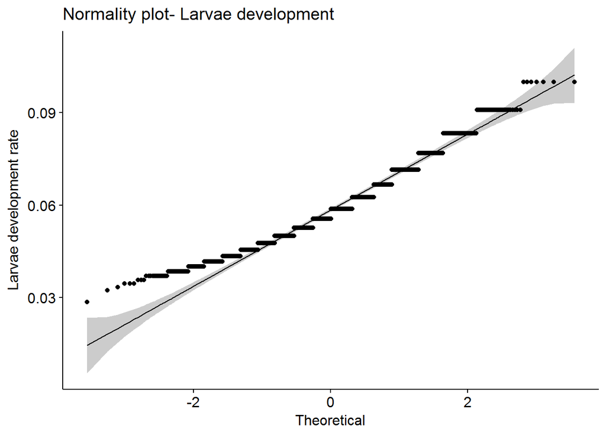

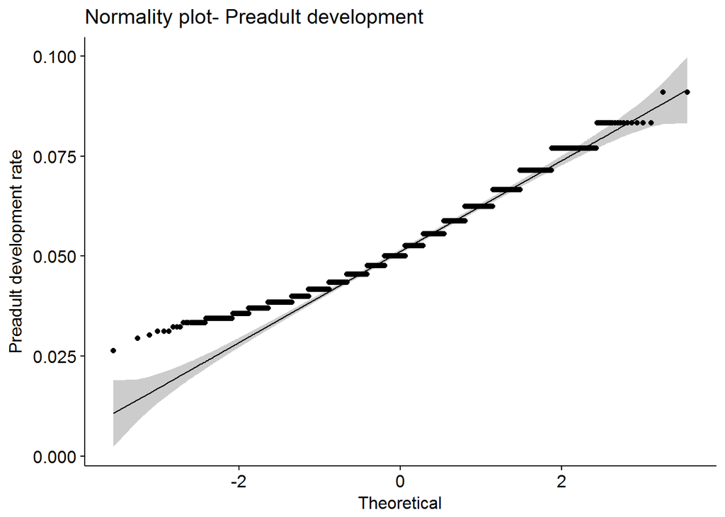

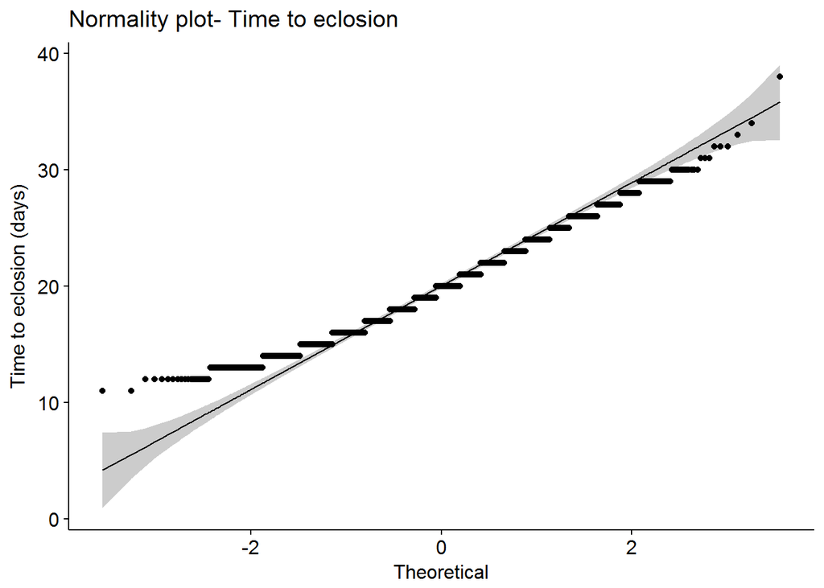

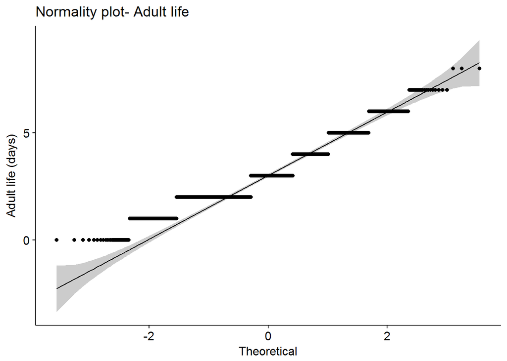

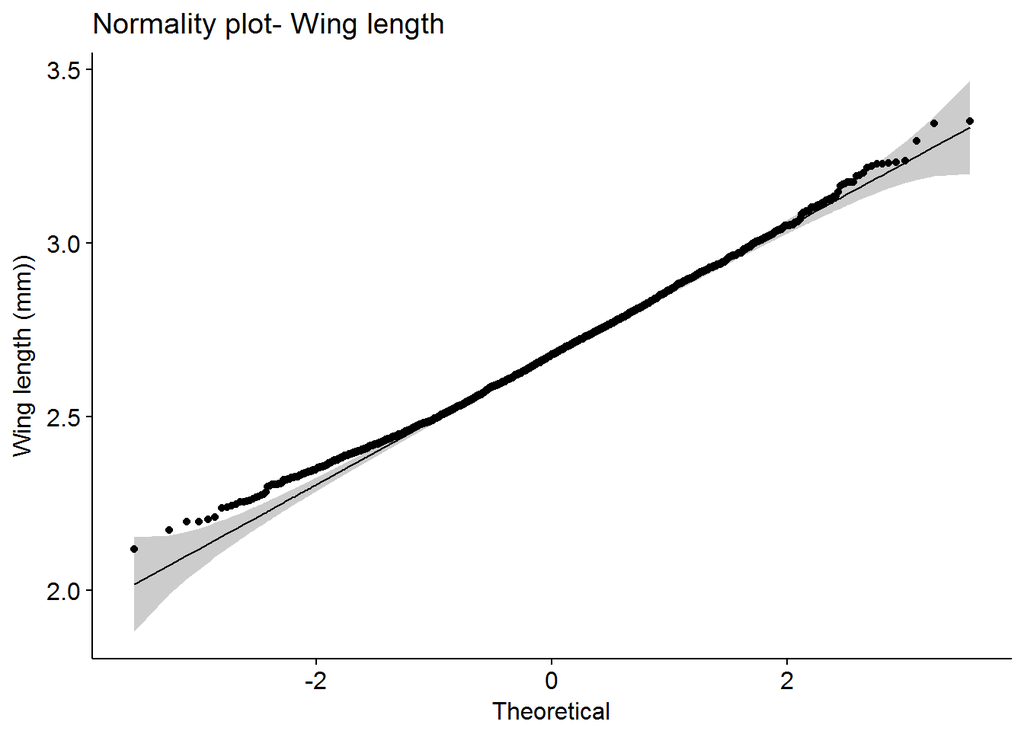

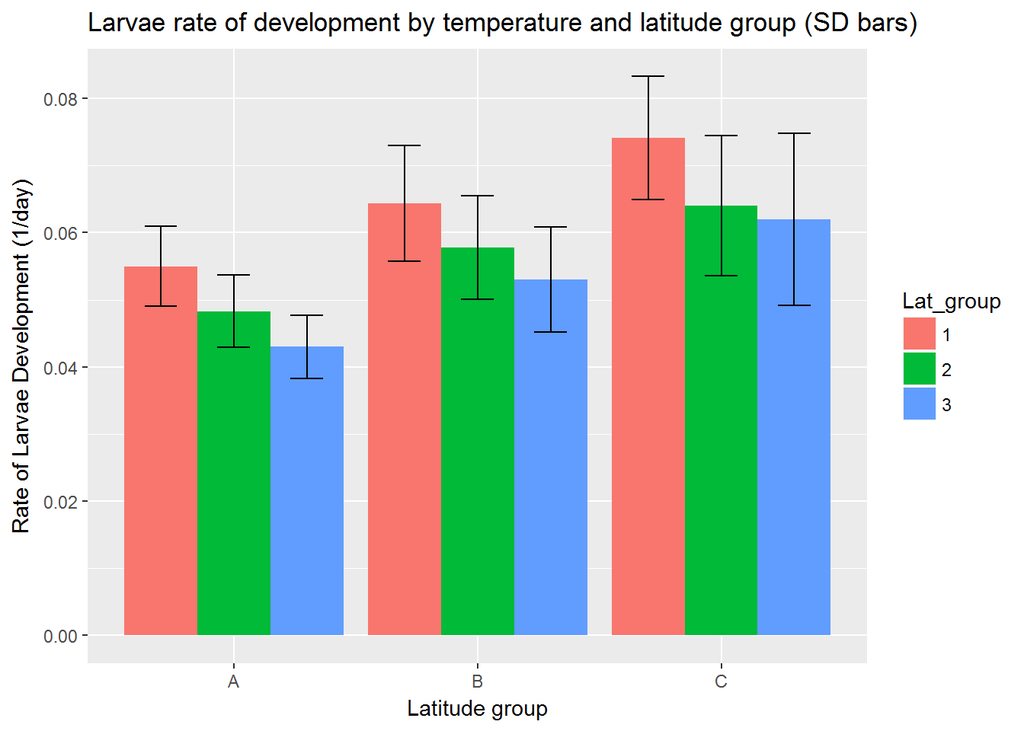

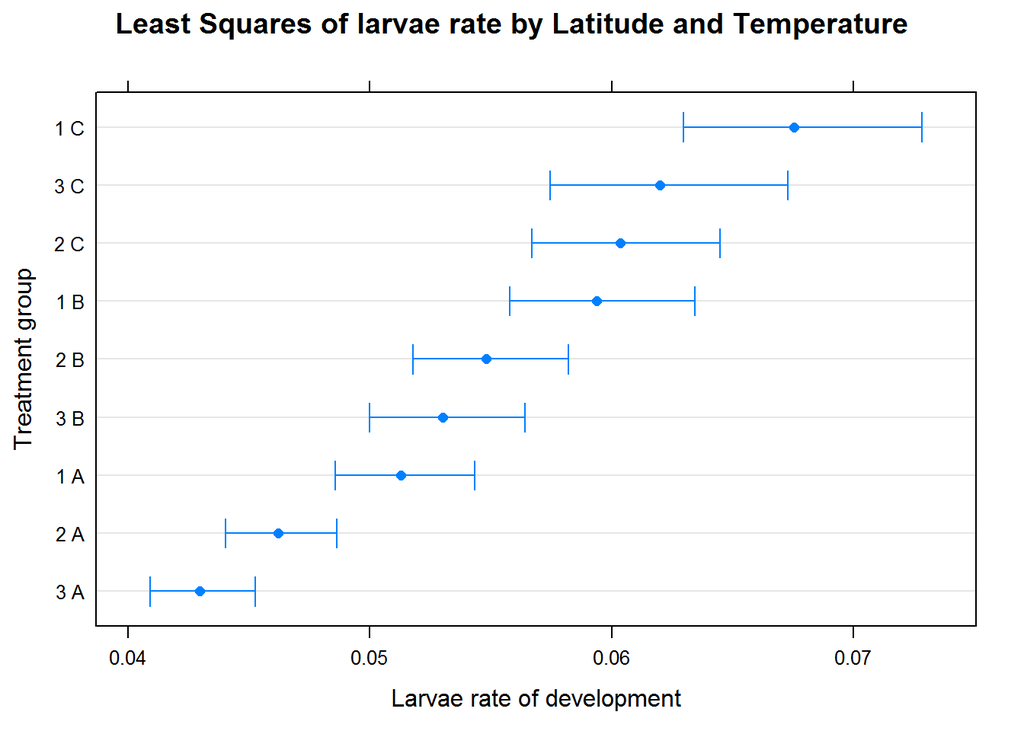

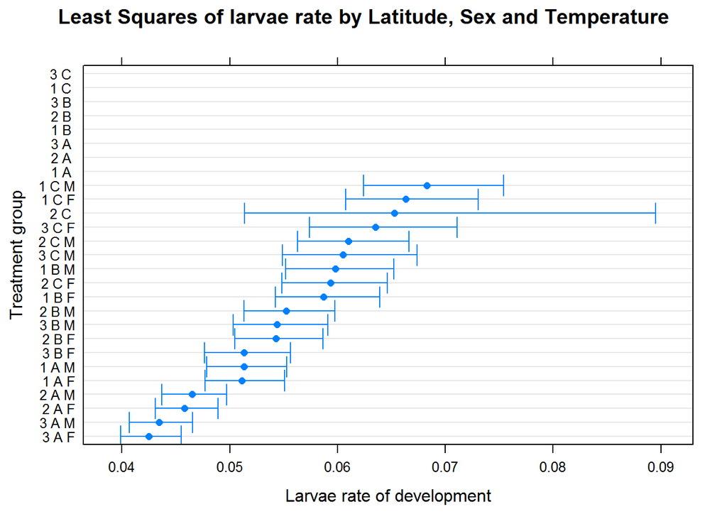

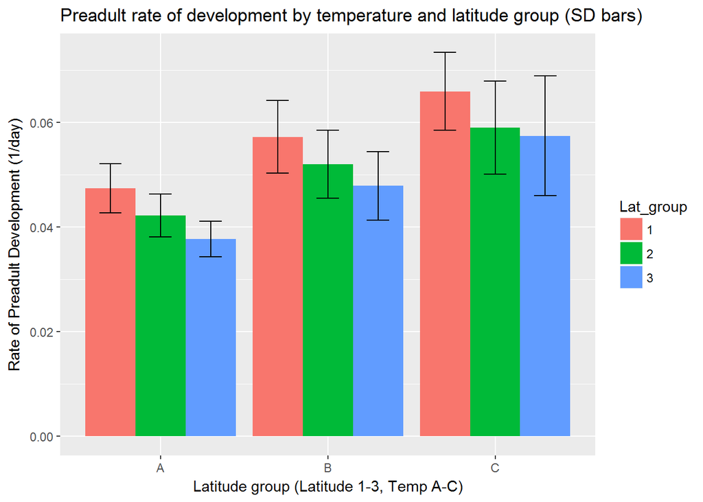

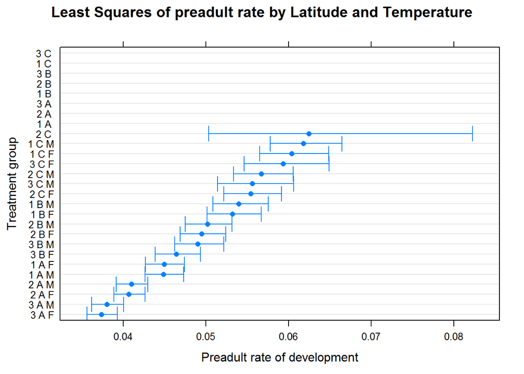

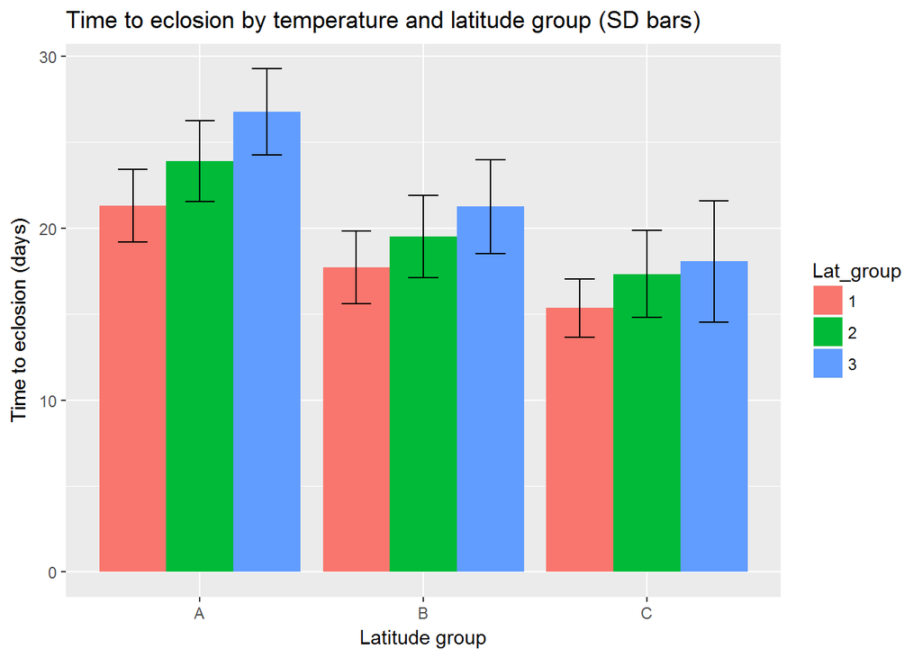

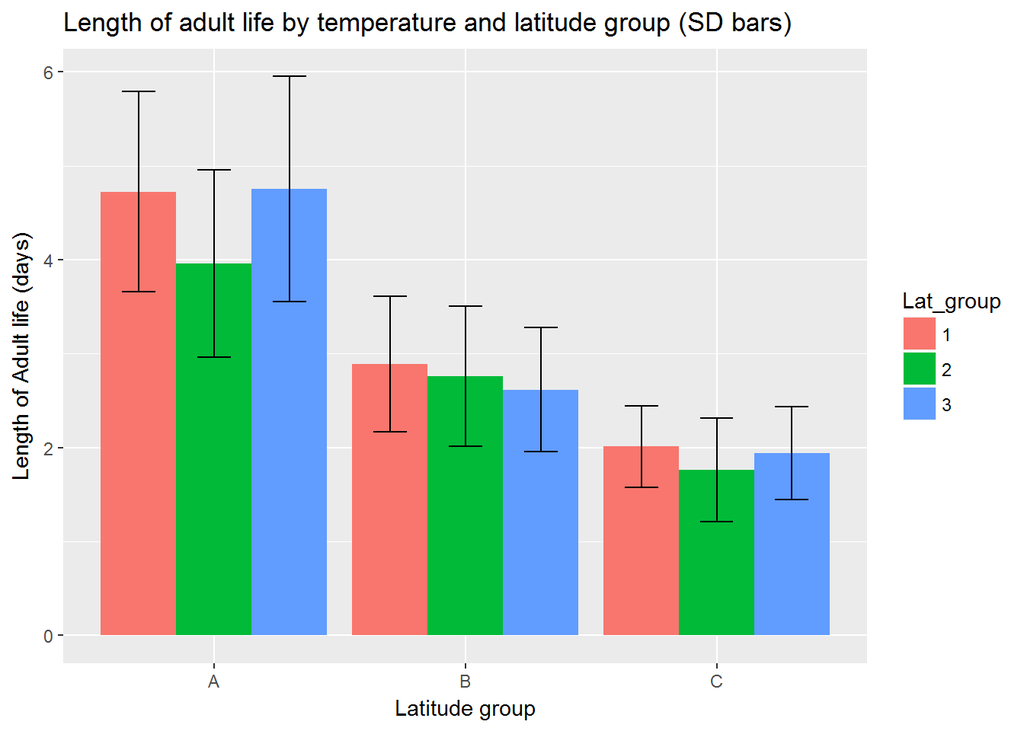

[3 more figures not shown]